# Makeover Monday 2020w22

Billy Caughey

May 31, 2020

## Purpose

It’s #MakeoverMonday again! I was super pumped to get into this weeks data. Then I saw the topic and felt sick. As an American, more specifically a white American male, this is something I have heard of but have very little context of. In some course work at the University of Utah, I heard of female genital mutilation but only in passing.

Now that I have had the time to read to documents, I’m excited to get into exploring this data set. Yes, I will little context outside the documents provided, but I will still do my very best to explore and find something cool! This topic deserves to be explored by the brightest minds to find a way to stop it.

The visual I will be trying to recreate or improve on is below in figure 1.

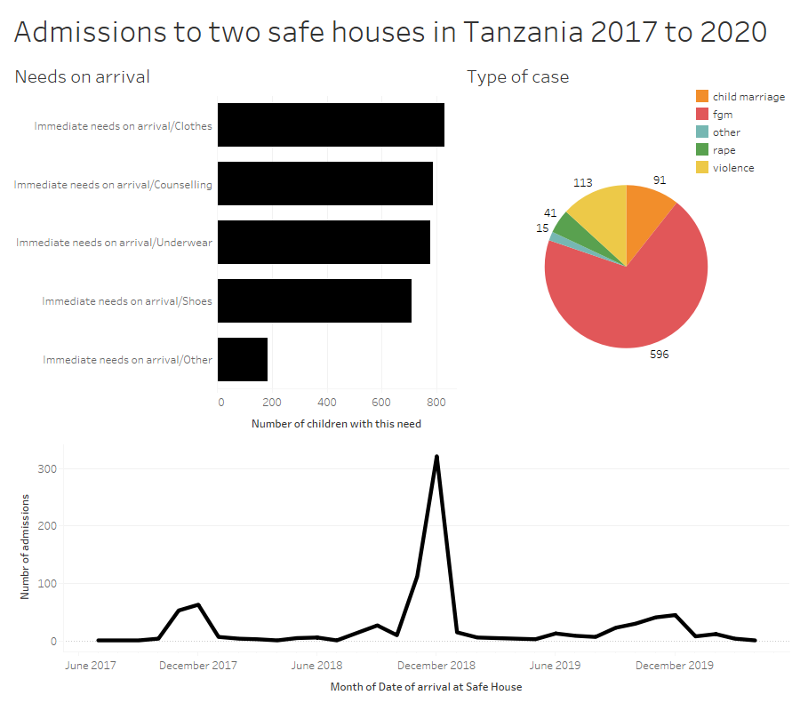

Fig. 1: Makeover Monday W22 Viz

## Data import

Let’s do what we normally do and import the data from data.world. This week’s data is in the form of a downloadable csv file. We will include some data clean up as well.

```r
library(tidyverse)
library(lubridate)

url <- "https://query.data.world/s/bpvpqxcoryydvbjzoaucp62jooect6"

df <- df <- read.csv(file = url, header=TRUE, stringsAsFactors=FALSE) %>%
  rename(arrival_date = Date.of.arrival.at.Safe.House,
         age_at_arrival = Age.on.arrival.in.years,
         school = Do.you.go.to.school.,
         type_of_case = Type.of.case,
         health_status_healthy = Health.Status.Healthy,
         health_status_sti = Health.Status.STI,
         health_status_uti = Health.Status.UTI,
         health_status_pregnant = Health.Status.Pregnant,
         health_status_other = Health.Status.Other.health.issue,
         needed_clothes = Immediate.needs.on.arrival.Clothes,
         needed_underwear = Immediate.needs.on.arrival.Underwear,
         needed_shoes = Immediate.needs.on.arrival.Shoes,
         needed_counselling = Immediate.needs.on.arrival.Counselling,
         needed_other = Immediate.needs.on.arrival.Other,
         who_brought_her = Who.brought.her.to.the.Safe.House,
         suggestions_from_swo = Suggestion.from.social.welfare.officer) %>%
  mutate(arrival_date = floor_date(as.Date(arrival_date, format = "%Y-%m-%d"),
                                   unit = "month"))

str(df)
```

```
FALSE 'data.frame': 851 obs. of  20 variables:
FALSE  $ ID                    : int  1 2 3 4 5 6 7 8 9 10 ...
FALSE  $ arrival_date          : Date, format: "2020-02-01" "2019-11-01" ...
FALSE  $ age_at_arrival        : int  14 18 11 14 12 13 12 13 11 13 ...
FALSE  $ school                : chr  "yes, used to go" "yes" "yes" "yes" ...
FALSE  $ Region                : chr  "Mara" "Mara" "Mara" "Mara" ...
FALSE  $ District              : chr  "Serengeti" "Butiam" "Serengeti" "Serengeti" ...
FALSE  $ Religion              : chr  "christian" "muslim" "christian" "christian" ...
FALSE  $ type_of_case          : chr  "other" "fgm" "fgm" "child marriage" ...
FALSE  $ health_status_healthy : int  1 1 0 0 0 0 0 0 0 0 ...
FALSE  $ health_status_sti     : int  0 0 0 0 0 0 0 0 0 0 ...
FALSE  $ health_status_uti     : int  0 0 1 1 1 1 1 1 1 1 ...
FALSE  $ health_status_pregnant: int  0 0 0 0 0 0 0 0 0 0 ...
FALSE  $ health_status_other   : int  0 0 0 0 0 0 0 0 0 0 ...
FALSE  $ needed_clothes        : int  1 1 0 1 0 1 0 1 1 1 ...
FALSE  $ needed_underwear      : int  1 1 1 0 0 0 1 1 1 0 ...
FALSE  $ needed_shoes          : int  0 0 1 1 1 1 1 1 0 1 ...
FALSE  $ needed_counselling    : int  0 1 1 1 1 1 1 1 1 1 ...
FALSE  $ needed_other          : int  1 0 0 0 0 0 0 0 0 0 ...
FALSE  $ who_brought_her       : chr  "government leader" "school teacher" "police" "police" ...
FALSE  $ suggestions_from_swo  : chr  "reconciliation with parents" "short term protection" "short term protection" "short term protection" ...
```

## Exploratory Data Analysis

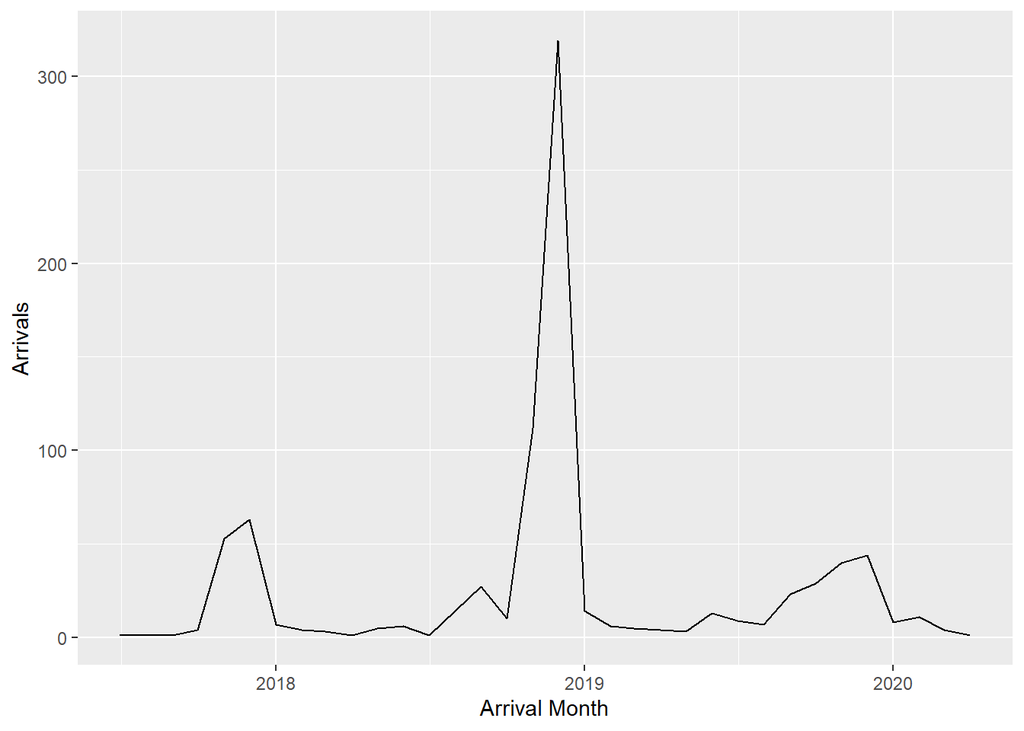

```r
df %>%
  select(arrival_date) %>%
  group_by(arrival_date) %>%
  summarize(arrivals = n()) %>%
  ggplot(aes(x = arrival_date, y = arrivals)) +
  geom_line() +
  xlab("Arrival Month") +
  ylab("Arrivals")
```

This looks similar to the figure we saw in the original visual. Now, let’s dig into where the girls are coming from over time.

```r
library(kableExtra)

table(df$Region) %>%
  kable(col.names = c("Region","Frequency"), align = 'lc') %>%
  kable_styling(bootstrap_options = c("striped","hover","condensed"),
                full_width = F)
```

| Region | Frequency |
| --- | --- |
| Arusha | 7 |
| Dodoma | 1 |
| Kagera | 1 |
| Kilimanjaro | 1 |
| Manyara | 1 |
| Mara | 828 |
| Mwanza | 10 |
| Singida | 2 |

The next question asked was who brought the women in to the Safe House? Like with the previous question, we start with a table. If there isn’t one that stands out, then the overtime visual will be produced.

```r
table(df$who_brought_her) %>%
  kable(col.names = c("Who","Frequency"), align = 'lc') %>%
  kable_styling(bootstrap_options = c("striped","hover","condensed"),
                full_width = F)
```

| Who | Frequency |
| --- | --- |
|  | 2 |
| came herself | 67 |
| community member | 30 |
| family member | 5 |
| government leader | 5 |
| other | 1 |
| police | 410 |
| religious leader | 26 |
| school teacher | 11 |
| social welfare officer | 18 |
| volunteer | 276 |